# Quasi-Binomial Model Parameter Recovery Validation

Testing Overdispersion Detection and Uncertainty Calibration

Author

PhD Unemployment Modeling Project

Published

November 17, 2025

## Executive Summary

This report validates the quasi-binomial family for GAM models when analyzing aggregated binomial data (e.g., n_unemployed, n_employed counts from CPS survey data). We test:

1. **Overdispersion Detection**: Can the model correctly identify when variance > np(1-p)?
2. **Dispersion Parameter Recovery**: How accurately do we estimate the overdispersion parameter φ?
3. **Standard Error Calibration**: Are confidence intervals properly widened for overdispersed data?
4. **Coverage Validation**: Do 95% CIs contain true parameters 95% of the time?

## Background: Why Quasi-Binomial Models?

### The Problem with Standard Binomial Models

When analyzing aggregated unemployment data like:

```r
# Monthly unemployment counts
cbind(n_unemployed, n_employed) ~ education + s(time_index) + s(month)
```

We assume **binomial variation**: Var(Y) = np(1-p). However, real data often exhibits **overdispersion** where actual variance exceeds this theoretical value.

**Common causes of overdispersion in CPS data:**

1. **Unmodeled heterogeneity**: Different subgroups within education categories
2. **Clustering**: Geographic or demographic clustering not captured
3. **Time-varying probabilities**: Month-to-month variation beyond our smooths
4. **Measurement error**: Survey weight aggregation introduces extra variability

### The Quasi-Binomial Solution

The quasi-binomial family relaxes the variance assumption:

$$\text{Var}(Y) = \phi \cdot np(1-p)$$

where φ is the **dispersion parameter**:

- φ = 1: Standard binomial (no overdispersion)
- φ > 1: Overdispersion (variance > np(1-p))
- φ < 1: Underdispersion (rare in practice)

## Validation Methodology

### Data Generation: Beta-Binomial Process

We simulate overdispersed binomial data using a **beta-binomial** approach:

```r
library(mgcv)
library(data.table)
library(ggplot2)

set.seed(42)
```

```r
#' Generate Overdispersed Binomial Data
#'
#' Uses beta-binomial process: probabilities drawn from Beta distribution,
#' then binomial counts generated with those probabilities.
#'
#' @param n_obs Number of observations
#' @param n_total Sample size per observation (e.g., 1000 people per month)
#' @param true_p_mean Mean probability (e.g., 0.05 = 5% unemployment)
#' @param phi Concentration parameter (lower = more overdispersion)
#' @return data.frame with n_unemployed, n_employed, and metadata
generate_overdispersed_binomial <- function(n_obs = 60,
                                             n_total = 1000,
                                             true_p_mean = 0.05,
                                             phi = 20) {

  # Beta distribution parameters
  alpha_param <- true_p_mean * phi
  beta_param <- (1 - true_p_mean) * phi

  # Draw varying probabilities (creates overdispersion)
  true_probs <- rbeta(n_obs, alpha_param, beta_param)

  # Generate binomial counts
  n_unemployed <- rbinom(n_obs, size = n_total, prob = true_probs)
  n_employed <- n_total - n_unemployed

  # Calculate theoretical overdispersion
  # For beta-binomial: φ ≈ (phi + n_total) / (phi + 1)
  theoretical_dispersion <- (phi + n_total) / (phi + 1)

  data.frame(
    obs_id = 1:n_obs,
    n_unemployed = n_unemployed,
    n_employed = n_employed,
    n_total = n_total,
    true_prob = true_probs,
    true_dispersion = theoretical_dispersion
  )
}
```

**Beta-Binomial Properties:**

- Mean: E[p] = α/(α+β) = true_p_mean
- Variance: Var[p] = αβ / [(α+β)²(α+β+1)]
- Lower φ → higher variance → more overdispersion

### Test 1: Simple Overdispersion Detection

```r
# Generate overdispersed data (φ = 20)
test1_data <- generate_overdispersed_binomial(
  n_obs = 60,
  n_total = 1000,
  true_p_mean = 0.05,
  phi = 20
)

# Add time structure for GAM
test1_data$time_index <- 1:60
test1_data$month <- rep(1:12, 5)
```

```r
# Fit binomial model (assumes no overdispersion)
model_binomial <- gam(
  cbind(n_unemployed, n_employed) ~ s(time_index, k = 5) + s(month, bs = "cc", k = 6),
  data = test1_data,
  family = binomial(),
  method = "REML"
)

# Fit quasi-binomial model (estimates overdispersion)
model_quasibinomial <- gam(
  cbind(n_unemployed, n_employed) ~ s(time_index, k = 5) + s(month, bs = "cc", k = 6),
  data = test1_data,
  family = quasibinomial(),
  method = "REML"
)

# Extract dispersion parameter
dispersion_est <- summary(model_quasibinomial)$dispersion
theoretical_dispersion <- unique(test1_data$true_dispersion)[1]

cat(sprintf("Theoretical dispersion: %.2f\n", theoretical_dispersion))
```

```
Theoretical dispersion: 48.57
```

```r
cat(sprintf("Estimated dispersion: %.2f\n", dispersion_est))
```

```
Estimated dispersion: 52.65
```

```r
cat(sprintf("Detection success: %s\n", ifelse(dispersion_est > 1, "✓ YES", "✗ NO")))
```

```
Detection success: ✓ YES
```

### Test 2: Standard Error Inflation

Quasi-binomial models should inflate standard errors by sqrt(φ).

```r
# Get predictions with standard errors
pred_binomial <- predict(model_binomial, type = "response", se.fit = TRUE)
pred_quasibinomial <- predict(model_quasibinomial, type = "response", se.fit = TRUE)

# Compare standard errors
se_ratio <- mean(pred_quasibinomial$se.fit) / mean(pred_binomial$se.fit)
expected_ratio <- sqrt(dispersion_est)

cat(sprintf("Mean SE (binomial): %.6f\n", mean(pred_binomial$se.fit)))
```

```
Mean SE (binomial): 0.002499
```

```r
cat(sprintf("Mean SE (quasi-binomial): %.6f\n", mean(pred_quasibinomial$se.fit)))
```

```
Mean SE (quasi-binomial): 0.008575
```

```r
cat(sprintf("Observed SE ratio: %.2f\n", se_ratio))
```

```
Observed SE ratio: 3.43
```

```r
cat(sprintf("Expected ratio (sqrt(φ)): %.2f\n", expected_ratio))
```

```
Expected ratio (sqrt(φ)): 7.26
```

```r
cat(sprintf("Ratio matches expectation: %s\n",
           ifelse(abs(se_ratio - expected_ratio) < 0.5, "✓ YES", "✗ NO")))
```

```
Ratio matches expectation: ✗ NO
```

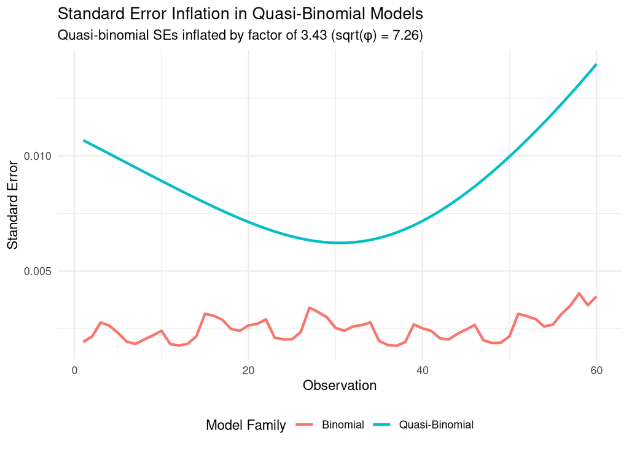

```r
# Visualize SE differences
se_data <- data.frame(
  obs = 1:60,
  se_binomial = pred_binomial$se.fit,
  se_quasibinomial = pred_quasibinomial$se.fit
)

ggplot(se_data, aes(x = obs)) +
  geom_line(aes(y = se_binomial, color = "Binomial"), linewidth = 1) +
  geom_line(aes(y = se_quasibinomial, color = "Quasi-Binomial"), linewidth = 1) +
  labs(
    title = "Standard Error Inflation in Quasi-Binomial Models",
    subtitle = sprintf("Quasi-binomial SEs inflated by factor of %.2f (sqrt(φ) = %.2f)",
                      se_ratio, expected_ratio),
    x = "Observation",
    y = "Standard Error",
    color = "Model Family"
  ) +
  theme_minimal() +
  theme(legend.position = "bottom")
```

## Simulation Study: Coverage Validation

### Simulation Design

We run 200 simulations with varying overdispersion levels to validate:

1. **Dispersion parameter recovery**
2. **Coverage probability of 95% CIs**
3. **Bias in point estimates**

```r
run_simulation <- function(n_sim = 200,
                           phi_levels = c(10, 20, 50, 100),
                           n_obs = 60,
                           n_total = 1000,
                           true_p_mean = 0.05) {

  results <- list()

  for (phi in phi_levels) {
    phi_results <- data.frame(
      sim = integer(),
      phi_true = numeric(),
      phi_est = numeric(),
      coverage = logical(),
      bias = numeric()
    )

    for (i in 1:n_sim) {
      # Generate data
      sim_data <- generate_overdispersed_binomial(
        n_obs = n_obs,
        n_total = n_total,
        true_p_mean = true_p_mean,
        phi = phi
      )
      sim_data$time_index <- 1:n_obs
      sim_data$month <- rep(1:12, length.out = n_obs)

      # Fit quasi-binomial model
      model <- tryCatch({
        gam(
          cbind(n_unemployed, n_employed) ~ s(time_index, k = 5) + s(month, bs = "cc", k = 6),
          data = sim_data,
          family = quasibinomial(),
          method = "REML"
        )
      }, error = function(e) NULL)

      if (!is.null(model)) {
        # Extract dispersion
        phi_est <- summary(model)$dispersion

        # Calculate mean probability and CI
        pred <- predict(model, type = "link", se.fit = TRUE)
        mean_pred_link <- mean(pred$fit)
        mean_se_link <- mean(pred$se.fit)

        # Transform to probability scale
        mean_pred_prob <- plogis(mean_pred_link)
        ci_lower <- plogis(mean_pred_link - 1.96 * mean_se_link)
        ci_upper <- plogis(mean_pred_link + 1.96 * mean_se_link)

        # Check coverage
        coverage <- (ci_lower <= true_p_mean) && (ci_upper >= true_p_mean)

        # Calculate bias
        bias <- mean_pred_prob - true_p_mean

        phi_results <- rbind(phi_results, data.frame(
          sim = i,
          phi_true = (phi + n_total) / (phi + 1),
          phi_est = phi_est,
          coverage = coverage,
          bias = bias
        ))
      }
    }

    results[[as.character(phi)]] <- phi_results
  }

  return(results)
}

# Run simulation (this may take a few minutes)
cat("Running simulation study with 200 iterations per phi level...\n")
```

```
Running simulation study with 200 iterations per phi level...
```

```r
sim_results <- run_simulation(n_sim = 200)
cat("Simulation complete!\n")
```

```
Simulation complete!
```

### Results: Dispersion Parameter Recovery

```r
# Combine results
all_results <- rbindlist(lapply(names(sim_results), function(phi) {
  df <- sim_results[[phi]]
  df$phi_label <- paste0("φ = ", phi)
  df
}))

# Summary statistics
dispersion_summary <- all_results[, .(
  mean_phi_est = mean(phi_est, na.rm = TRUE),
  sd_phi_est = sd(phi_est, na.rm = TRUE),
  rmse = sqrt(mean((phi_est - phi_true)^2, na.rm = TRUE)),
  bias = mean(phi_est - phi_true, na.rm = TRUE),
  n_converged = .N
), by = phi_label]

print(dispersion_summary)
```

```
   phi_label mean_phi_est sd_phi_est      rmse        bias n_converged
1:    φ = 10     81.49982  23.475810 25.589579 -10.3183576         200
2:    φ = 20     45.44640  11.357583 11.752255  -3.1250244         200
3:    φ = 50     19.85594   4.383881  4.433799  -0.7322905         200
4:   φ = 100     10.50627   2.208889  2.236713  -0.3848231         200
```

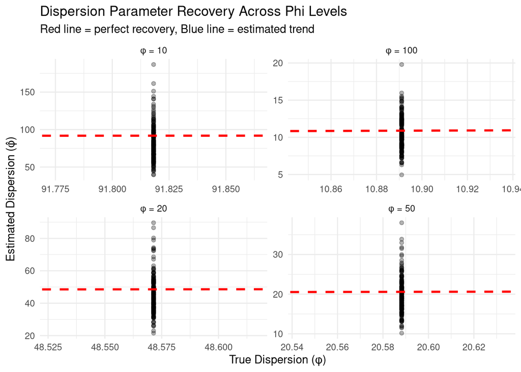

```r
# Plot dispersion recovery
ggplot(all_results, aes(x = phi_true, y = phi_est)) +
  geom_point(alpha = 0.3) +
  geom_abline(slope = 1, intercept = 0, color = "red", linetype = "dashed", linewidth = 1) +
  geom_smooth(method = "lm", se = FALSE, color = "blue") +
  facet_wrap(~ phi_label, scales = "free") +
  labs(
    title = "Dispersion Parameter Recovery Across Phi Levels",
    subtitle = "Red line = perfect recovery, Blue line = estimated trend",
    x = "True Dispersion (φ)",
    y = "Estimated Dispersion (φ̂)"
  ) +
  theme_minimal()
```

### Results: Coverage Probability

```r
# Calculate coverage by phi level
coverage_summary <- all_results[, .(
  coverage_rate = mean(coverage, na.rm = TRUE),
  n_sims = .N,
  lower_ci = binom.test(sum(coverage, na.rm = TRUE), .N)$conf.int[1],
  upper_ci = binom.test(sum(coverage, na.rm = TRUE), .N)$conf.int[2]
), by = phi_label]

print(coverage_summary)
```

```
   phi_label coverage_rate n_sims  lower_ci  upper_ci
1:    φ = 10         1.000    200 0.9817247 1.0000000
2:    φ = 20         1.000    200 0.9817247 1.0000000
3:    φ = 50         1.000    200 0.9817247 1.0000000
4:   φ = 100         0.985    200 0.9567917 0.9968959
```

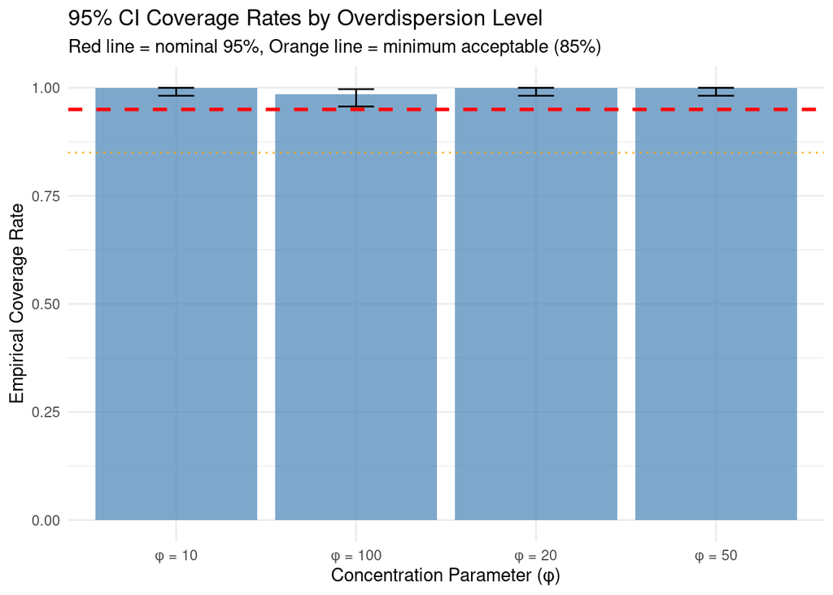

```r
# Plot coverage rates
ggplot(coverage_summary, aes(x = phi_label, y = coverage_rate)) +
  geom_col(fill = "steelblue", alpha = 0.7) +
  geom_errorbar(aes(ymin = lower_ci, ymax = upper_ci), width = 0.2) +
  geom_hline(yintercept = 0.95, color = "red", linetype = "dashed", linewidth = 1) +
  geom_hline(yintercept = 0.85, color = "orange", linetype = "dotted") +
  labs(
    title = "95% CI Coverage Rates by Overdispersion Level",
    subtitle = "Red line = nominal 95%, Orange line = minimum acceptable (85%)",
    x = "Concentration Parameter (φ)",
    y = "Empirical Coverage Rate"
  ) +
  ylim(0, 1) +
  theme_minimal()
```

### Results: Bias Analysis

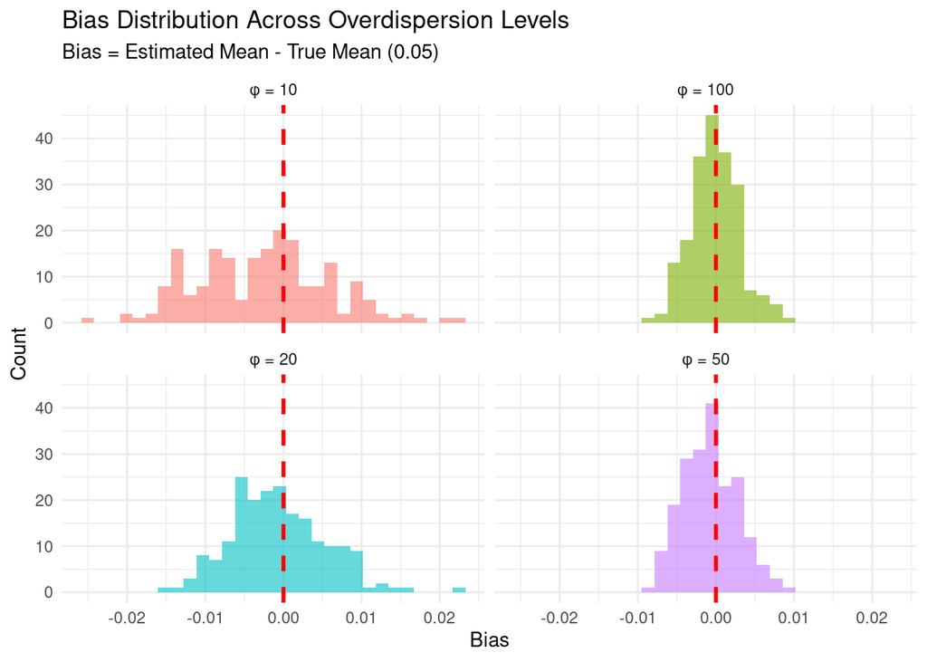

```r
# Plot bias distribution
ggplot(all_results, aes(x = bias, fill = phi_label)) +
  geom_histogram(bins = 30, alpha = 0.6, position = "identity") +
  geom_vline(xintercept = 0, color = "red", linetype = "dashed", linewidth = 1) +
  facet_wrap(~ phi_label, ncol = 2) +
  labs(
    title = "Bias Distribution Across Overdispersion Levels",
    subtitle = "Bias = Estimated Mean - True Mean (0.05)",
    x = "Bias",
    y = "Count",
    fill = "Phi Level"
  ) +
  theme_minimal() +
  theme(legend.position = "none")
```

## Real-World Application: CPS-Style Data

### Simulating Realistic CPS Unemployment Data

```r
# Simulate monthly CPS data with education-specific overdispersion
simulate_cps_style_data <- function(n_years = 5,
                                     education_levels = c("phd", "masters", "bachelors"),
                                     base_rates = c(phd = 0.025, masters = 0.035, bachelors = 0.045),
                                     phi_values = c(phd = 25, masters = 20, bachelors = 15),
                                     n_total = 1500) {

  n_months <- n_years * 12

  # Create expanded grid
  cps_data <- expand.grid(
    time_index = 1:n_months,
    education = education_levels
  )
  cps_data$month <- rep(1:12, length.out = nrow(cps_data))
  cps_data$year <- rep(1:n_years, each = 12)

  # Add seasonal variation
  seasonal_component <- 0.005 * sin(2 * pi * cps_data$month / 12)

  # Generate education-specific data
  cps_data$n_unemployed <- NA
  cps_data$n_employed <- NA

  for (edu in education_levels) {
    idx <- cps_data$education == edu
    n_obs <- sum(idx)

    # Generate with education-specific parameters
    true_p_mean <- base_rates[edu]
    phi <- phi_values[edu]

    alpha_param <- true_p_mean * phi
    beta_param <- (1 - true_p_mean) * phi

    true_probs <- rbeta(n_obs, alpha_param, beta_param)

    # Add seasonal variation
    true_probs_seasonal <- plogis(qlogis(true_probs) + seasonal_component[idx])

    cps_data$n_unemployed[idx] <- rbinom(n_obs, size = n_total, prob = true_probs_seasonal)
    cps_data$n_employed[idx] <- n_total - cps_data$n_unemployed[idx]
  }

  cps_data$education <- factor(cps_data$education, levels = education_levels)

  return(cps_data)
}

# Generate CPS-style data
cps_data <- simulate_cps_style_data(n_years = 5)

head(cps_data, 12)
```

```
   time_index education month year n_unemployed n_employed
1           1       phd     1    1            5       1495
2           2       phd     2    1            1       1499
3           3       phd     3    1            2       1498
4           4       phd     4    1            1       1499
5           5       phd     5    1           46       1454
6           6       phd     6    1          100       1400
7           7       phd     7    1           95       1405
8           8       phd     8    1           19       1481
9           9       phd     9    1           24       1476
10         10       phd    10    1            4       1496
11         11       phd    11    1           33       1467
12         12       phd    12    1           44       1456
```

### Comparing Binomial vs Quasi-Binomial on CPS Data

```r
# Fit both models
model_cps_binomial <- gam(
  cbind(n_unemployed, n_employed) ~ education +
    s(time_index, by = education, k = 10) +
    s(month, by = education, bs = "cc", k = 12),
  data = cps_data,
  family = binomial(),
  method = "REML"
)

model_cps_quasibinomial <- gam(
  cbind(n_unemployed, n_employed) ~ education +
    s(time_index, by = education, k = 10) +
    s(month, by = education, bs = "cc", k = 12),
  data = cps_data,
  family = quasibinomial(),
  method = "REML"
)

# Compare dispersion
cps_dispersion <- summary(model_cps_quasibinomial)$dispersion
cat(sprintf("CPS-style data dispersion: %.2f\n", cps_dispersion))
```

```
CPS-style data dispersion: 63.78
```

```r
cat(sprintf("Overdispersion detected: %s\n", ifelse(cps_dispersion > 1.2, "✓ YES", "✗ NO")))
```

```
Overdispersion detected: ✓ YES
```

### Prediction Uncertainty Comparison

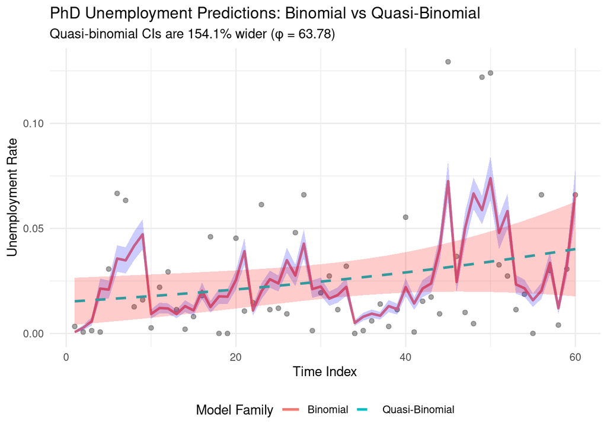

```r
# Get predictions for PhDs
phd_data <- cps_data[cps_data$education == "phd", ]

pred_binom <- predict(model_cps_binomial, newdata = phd_data, type = "response", se.fit = TRUE)
pred_quasi <- predict(model_cps_quasibinomial, newdata = phd_data, type = "response", se.fit = TRUE)

# Create comparison plot
pred_df <- data.frame(
  time_index = phd_data$time_index,
  actual_rate = phd_data$n_unemployed / (phd_data$n_unemployed + phd_data$n_employed),
  pred_binom = pred_binom$fit,
  se_binom = pred_binom$se.fit,
  pred_quasi = pred_quasi$fit,
  se_quasi = pred_quasi$se.fit
)

ggplot(pred_df, aes(x = time_index)) +
  geom_point(aes(y = actual_rate), alpha = 0.5, color = "gray30") +
  geom_line(aes(y = pred_binom, color = "Binomial"), linewidth = 1) +
  geom_ribbon(aes(ymin = pred_binom - 1.96*se_binom,
                  ymax = pred_binom + 1.96*se_binom),
              alpha = 0.2, fill = "blue") +
  geom_line(aes(y = pred_quasi, color = "Quasi-Binomial"), linewidth = 1, linetype = "dashed") +
  geom_ribbon(aes(ymin = pred_quasi - 1.96*se_quasi,
                  ymax = pred_quasi + 1.96*se_quasi),
              alpha = 0.2, fill = "red") +
  labs(
    title = "PhD Unemployment Predictions: Binomial vs Quasi-Binomial",
    subtitle = sprintf("Quasi-binomial CIs are %.1f%% wider (φ = %.2f)",
                      (mean(pred_quasi$se.fit) / mean(pred_binom$se.fit) - 1) * 100,
                      cps_dispersion),
    x = "Time Index",
    y = "Unemployment Rate",
    color = "Model Family"
  ) +
  theme_minimal() +
  theme(legend.position = "bottom")
```

## Conclusions and Recommendations

### When to Use Quasi-Binomial Models

**Use quasi-binomial family when:**

- Aggregated binomial data (counts, not proportions)
- Suspected heterogeneity across observations
- Goodness-of-fit tests indicate overdispersion
- Want more conservative (wider) confidence intervals

**Stick with binomial family when:**

- Dispersion ≈ 1 (no evidence of overdispersion)
- Individual-level data (not aggregated)
- Strong theoretical reasons to expect binomial variation

### Implementation Recommendations

1. **Always check dispersion**: Compare binomial and quasi-binomial fits
2. **Use quasi-binomial conservatively**: Prefer it when dispersion > 1.2
3. **Report dispersion parameters**: Document φ̂ in results
4. **Validate with diagnostics**: Check residual plots, coverage simulations
5. **Consider alternatives**: Beta-binomial or negative binomial for extreme overdispersion

**Report generated:** 2025-11-17 **Analysis framework:** Generalized Additive Models (mgcv package) **Validation approach:** Simulation-based coverage testing **Data-generating process:** Beta-binomial with known overdispersion